# TP 1 - Modèle linéaire

Les librairies R nécessaires pour ce TP :

```r
library(ellipse)
library(leaps)
library(MASS)
library(corrplot)
library(glmnet)
library(ggplot2)
library(gridExtra)
library(ggfortify)
library(plotly)
library(tidyverse)
library(FactoMineR)
```

# Présentation des données

La pollution de l’air constitue actuellement une des préoccupations majeures de santé publique. De nombreuses études épidémiologiques ont permis de mettre en évidence l’influence sur la santé de certains composés chimiques comme le dioxyde souffre (SO2), le dioxyde d’azote (NO2), l’ozone (O3) ou des particules en suspension. Des associations de surveillance de la qualité de l’air (Air Breizh en Bretagne depuis 1994) existent sur tout le territoire métropolitain et mesurent la concentration des polluants. Elles enregistrent également les conditions météorologiques comme la température, la nébulosité, le vent, les chutes de pluie en relation avec les services de Météo France… L’une des missions de ces associations est de construire des modèles de prévision de la concentration en ozone du lendemain à partir des données disponibles du jour : observations et prévisions de Météo France. Plus précisément, il s’agit d’anticiper l’occurrence ou non d’un dépassement légal du pic d’ozone (180 $\mu$gr/m3) le lendemain afin d’aider les services préfectoraux à prendre les décisions nécessaires de prévention : confinement des personnes à risque, limitation du trafic routier. Plus modestement, l’objectif de cette étude est de mettre en évidence l’influence de certains paramètres sur la concentration d’ozone (en $\mu$gr/m3) et différentes variables observées ou leur prévision. Les 112 données étudiées ont été recueillies à Rennes durant l’été 2001.

Les 13 variables observées sont :

- maxO3 : Maximum de concentration d’ozone observé sur la journée en $\mu$gr/m3
- T9, T12, T15 : Température observée à 9, 12 et 15h
- Ne9, Ne12, Ne15 : Nébulosité observée à 9, 12 et 15h
- Vx9, Vx12, Vx15 : Composante E-O du vent à 9, 12 et 15h
- maxO3v : Teneur maximum en ozone observée la veille
- vent : orientation du vent à 12h
- pluie : occurrence ou non de précipitations

Les données sont disponibles dans le fichier “Ozone.txt” sur la page https://github.com/cmaugis/Stat-Avancees---PFB-Toulouse (dossier Data/).

Pour les lire, vous pouvez utiliser la commande suivante :

```r
url <- url("https://raw.githubusercontent.com/cmaugis/Stat-Avancees---PFB-Toulouse/main/Data/Ozone.txt")
ozone = read.table(url)
```

```r
ozone$vent <- as.factor(ozone$vent)
ozone$pluie <- as.factor(ozone$pluie)
summary(ozone)
```

```
     maxO3              T9             T12             T15
 Min.   : 42.00   Min.   :11.30   Min.   :14.00   Min.   :14.90
 1st Qu.: 70.75   1st Qu.:16.20   1st Qu.:18.60   1st Qu.:19.27
 Median : 81.50   Median :17.80   Median :20.55   Median :22.05
 Mean   : 90.30   Mean   :18.36   Mean   :21.53   Mean   :22.63
 3rd Qu.:106.00   3rd Qu.:19.93   3rd Qu.:23.55   3rd Qu.:25.40
      Ne9             Ne12            Ne15           Vx9
 Min.   :0.000   Min.   :0.000   Min.   :0.00   Min.   :-7.8785
 1st Qu.:3.000   1st Qu.:4.000   1st Qu.:3.00   1st Qu.:-3.2765
 Median :6.000   Median :5.000   Median :5.00   Median :-0.8660
 Mean   :4.929   Mean   :5.018   Mean   :4.83   Mean   :-1.2143
 3rd Qu.:7.000   3rd Qu.:7.000   3rd Qu.:7.00   3rd Qu.: 0.6946
      Vx12             Vx15            maxO3v          vent      pluie
 Min.   :-7.878   Min.   :-9.000   Min.   : 42.00   Est  :10   Pluie:43
 1st Qu.:-3.565   1st Qu.:-3.939   1st Qu.: 71.00   Nord :31   Sec  :69
 Median :-1.879   Median :-1.550   Median : 82.50   Ouest:50
 Mean   :-1.611   Mean   :-1.691   Mean   : 90.57   Sud  :21
 3rd Qu.: 0.000   3rd Qu.: 0.000   3rd Qu.:106.00
 [ getOption("max.print") est atteint -- ligne 1 omise ]
```

# Quelques statistiques descriptives

Afin de se familiariser avec les données, nous allons faire quelques statistiques descriptives.

Distribution des variables quantitatives :

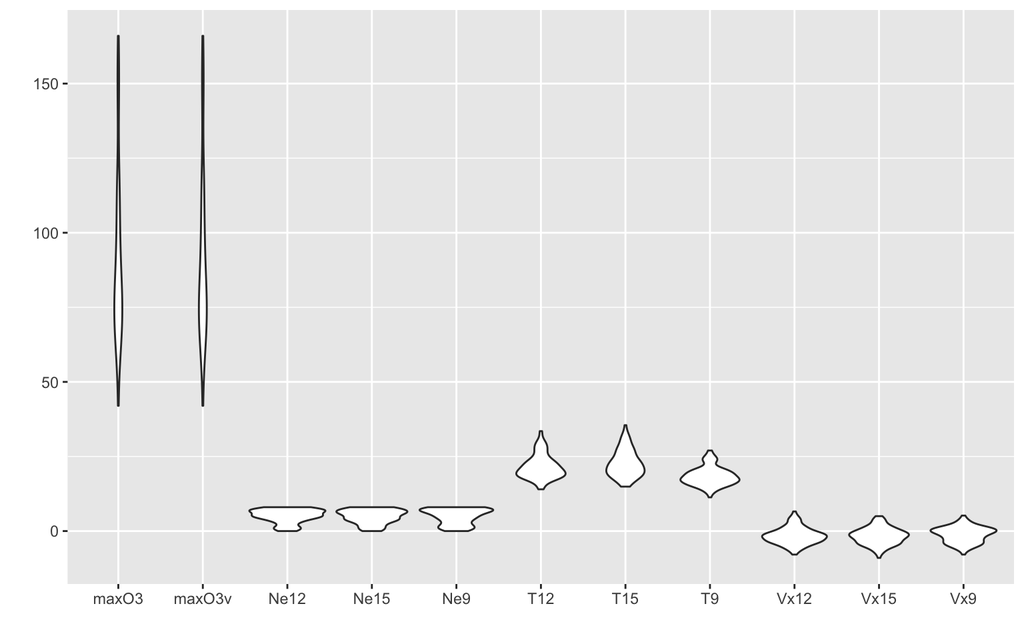

```r
oz_quanti <- ozone[, 1:11]
A <- data.frame(y = as.vector(as.matrix(t(oz_quanti))), x = rep(colnames(oz_quanti),
    nrow(oz_quanti)))
ggplot(A, aes(x = x, y = y)) + geom_violin() + xlab("") + ylab("")
```

Répartition des variables qualitatives *vent* et *pluie* :

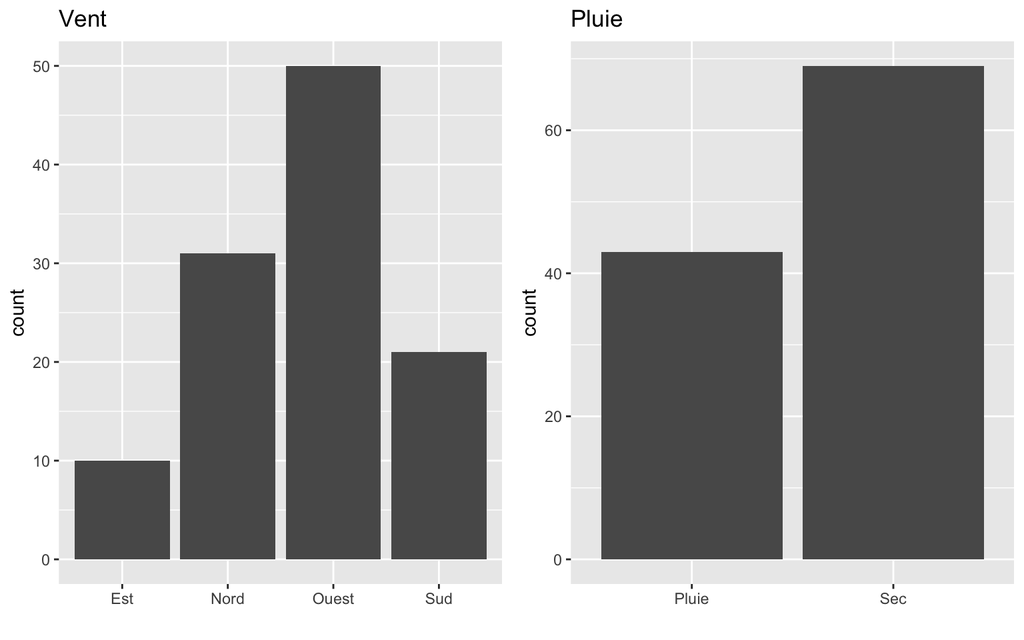

```r
g1 <- ggplot(ozone, aes(x = vent)) + geom_bar() + xlab("") + ggtitle("Vent")
g2 <- ggplot(ozone, aes(x = pluie)) + geom_bar() + xlab("") + ggtitle("Pluie")
grid.arrange(g1, g2, ncol = 2)
```

Matrice des corrélations entre variables quantitatives :

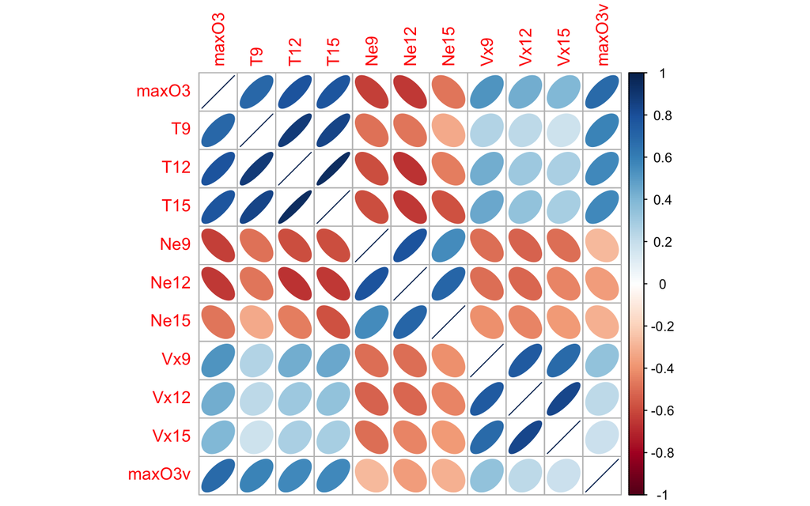

```r
corrplot(cor(oz_quanti), method = "ellipse")
```

Analyse en composantes principales :

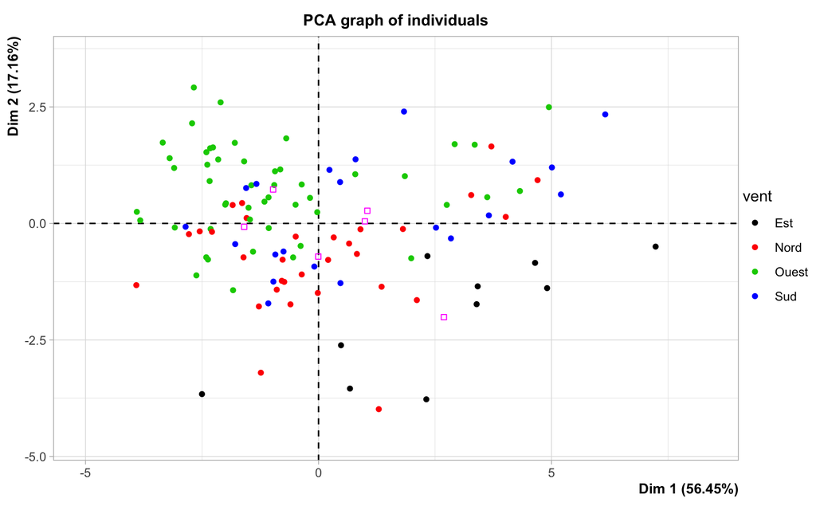

```r
respca <- PCA(ozone, scale.unit = TRUE, quali.sup = c(12, 13), graph = FALSE)
plot(respca, choix = "ind", habillage = 12, label = "none")
```

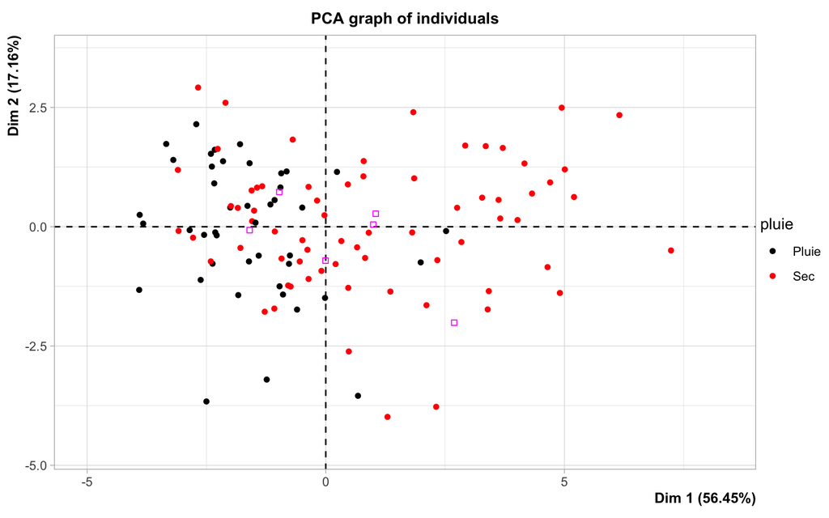

```r
plot(respca, choix = "ind", habillage = 13, label = "none")
```

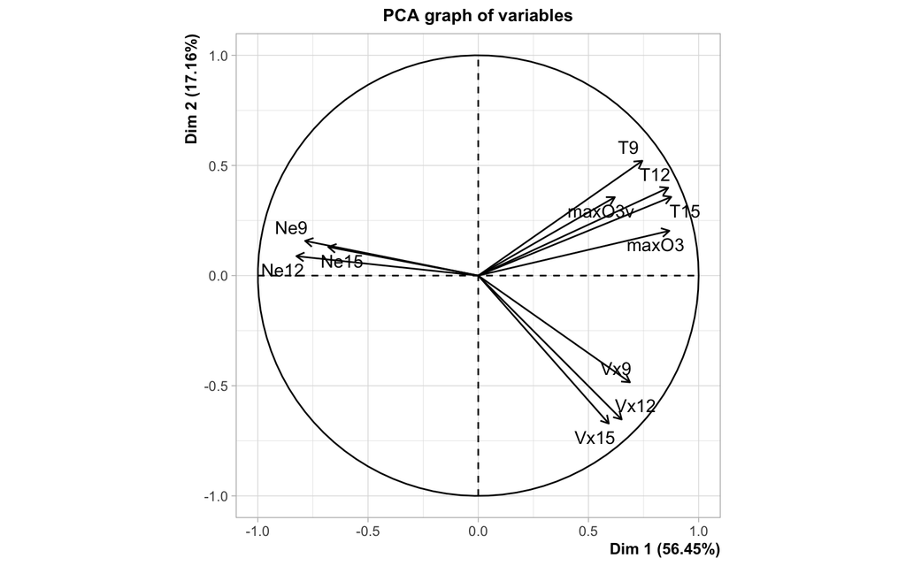

```r
plot(respca, choix = "varcor")
```

# Régression linéaire

Dans cette partie, nous souhaitons analyser la relation entre le maximum journalier de la concentration d’ozone ($y=$*maxO3*) et les variables ($x$) quantitatives :

- la température à différentes heures de la journée (*T9, T12, T15*),
- la nébulosité à différentes heures de la journée (*Ne9, Ne12, Ne15*),
- la projection du vent sur l’axe Est-Ouest à différentes heures de la journée (*Vx9, Vx12,Vx15*),
- la concentration maximale d’ozone de la veille (*maxO3v*)

On va donc utiliser le sous-jeu de données `oz_quanti` et mettre en place un modèle de régression linéaire multiple.

## Question 1

### Enoncé

Représentez le nuage de points $(x_i,y_i)$ à l’aide de la fonction `plot()` (ou `geom_point` de *ggplot2*) de maxO3 par rapport à T12, Ne9, Vx15 et maxO3v respectivement.

```r
# A COMPLETER
```

Commentez.

### Correction

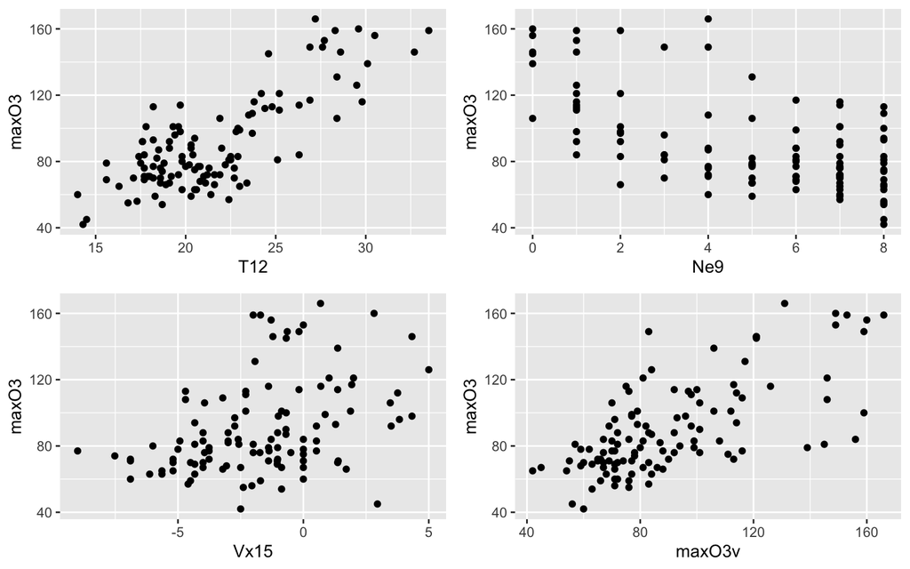

```r
g1 <- ggplot(oz_quanti, aes(x = T12, y = maxO3)) + geom_point()
g2 <- ggplot(oz_quanti, aes(x = Ne9, y = maxO3)) + geom_point()
g3 <- ggplot(oz_quanti, aes(x = Vx15, y = maxO3)) + geom_point()
g4 <- ggplot(oz_quanti, aes(x = maxO3v, y = maxO3)) + geom_point()
grid.arrange(g1, g2, g3, g4, ncol = 2)
```

## Question 2

### Enoncé

Effectuez la régression linéaire à l’aide de la fonction `lm()` et exploitez les résultats.

```r
# A COMPLETER reg <-lm(....)
```

Que contiennent les sorties suivantes ?

```r
reg$coefficients
reg$residuals
```

### Correction

```r
reg = lm(maxO3 ~ ., data = oz_quanti)
summary(reg)
```

```
Call:
lm(formula = maxO3 ~ ., data = oz_quanti)

Residuals:
    Min      1Q  Median      3Q     Max
-53.566  -8.727  -0.403   7.599  39.458

Coefficients:
            Estimate Std. Error t value Pr(>|t|)
(Intercept) 12.24442   13.47190   0.909   0.3656
T9          -0.01901    1.12515  -0.017   0.9866
T12          2.22115    1.43294   1.550   0.1243
T15          0.55853    1.14464   0.488   0.6266
Ne9         -2.18909    0.93824  -2.333   0.0216 *
Ne12        -0.42102    1.36766  -0.308   0.7588
Ne15         0.18373    1.00279   0.183   0.8550
Vx9          0.94791    0.91228   1.039   0.3013
Vx12         0.03120    1.05523   0.030   0.9765
Vx15         0.41859    0.91568   0.457   0.6486
maxO3v       0.35198    0.06289   5.597 1.88e-07 ***
---
Signif. codes:  0 '***' 0.001 '**' 0.01 '*' 0.05 '.' 0.1 ' ' 1

Residual standard error: 14.36 on 101 degrees of freedom
Multiple R-squared:  0.7638,    Adjusted R-squared:  0.7405
F-statistic: 32.67 on 10 and 101 DF,  p-value: < 2.2e-16
```

Modèle :
$$maxO3_i = \theta_0 + \theta_1 T9_i + \theta_2 T12_i +\ldots+ \theta_{10} maxO3v_i + \varepsilon_i,\ \forall i\in\{1,\ldots,n\}$$
$$\varepsilon_i\underset{i.i.d}{\sim}\mathcal{N}(0,\sigma^2)$$

Interprétation : On récupère les estimations des paramètres $(\theta_0,\ldots,\theta_{10})$ et $\sqrt{\sigma^2}$ (*Residual standard error*). On ne rejette pas la nullité de nombreux paramètres séparement, on eput certainement simplifier le modèle en faisant de la sélection de variables (voir Partie 2). On obtient un $R^2 = 0.7638$.

La commande `reg$coefficients` permet de récupérer les estimations du verteur des paramètres $\theta$

```r
reg$coefficients
```

```
(Intercept)          T9         T12         T15         Ne9        Ne12
12.24441987 -0.01901425  2.22115189  0.55853087 -2.18909215 -0.42101517
       Ne15         Vx9        Vx12        Vx15      maxO3v
 0.18373097  0.94790917  0.03119824  0.41859252  0.35197646
```

La commande `reg$residuals` contient les valeurs des résidus $\hat\varepsilon_i = y_i - \hat y_i = y_i - \hat\theta_0 - \hat\theta_1 x_i$.

## Question 3

### Enoncé

A l’aide de la fonction `autoplot()` du package *ggfortify*, etudiez les résidus du modèle afin de vérifier les hypothèses du modèle.

```r
# autoplot(...)
```

### Correction

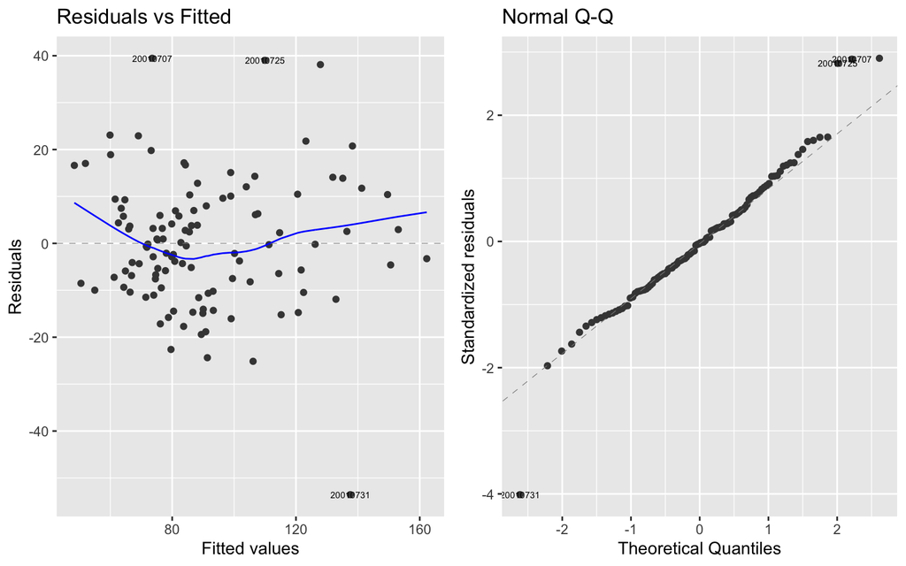

```r
autoplot(reg, label.size = 2, which = 1:2)
```

## Question 4

### Enoncé

A l’aide d’une procédure de sélection de variables (que l’on étudiera plus précisément dans la partie 2 du cours), un sous-modèle avec les variables explicatives T12, Ne9, Vx9 et maxO3v est proposé pour expliquer linéairement maxO3.  
A l’aide de la fonction `anova()` testez si on peut retenir ce sous-modèle par rappport au modèle complet. Commentez.

```r
reg.fin <- lm(...)
anova(reg.fin, reg)
```

### Correction

```r
reg.fin <- lm(maxO3 ~ T12 + Ne9 + Vx9 + maxO3v, data = oz_quanti)
summary(reg.fin)
```

```
Call:
lm(formula = maxO3 ~ T12 + Ne9 + Vx9 + maxO3v, data = oz_quanti)

Residuals:
    Min      1Q  Median      3Q     Max
-52.396  -8.377  -1.086   7.951  40.933

Coefficients:
            Estimate Std. Error t value Pr(>|t|)
(Intercept) 12.63131   11.00088   1.148 0.253443
T12          2.76409    0.47450   5.825 6.07e-08 ***
Ne9         -2.51540    0.67585  -3.722 0.000317 ***
Vx9          1.29286    0.60218   2.147 0.034055 *
maxO3v       0.35483    0.05789   6.130 1.50e-08 ***
---
Signif. codes:  0 '***' 0.001 '**' 0.01 '*' 0.05 '.' 0.1 ' ' 1

Residual standard error: 14 on 107 degrees of freedom
Multiple R-squared:  0.7622,    Adjusted R-squared:  0.7533
F-statistic: 85.75 on 4 and 107 DF,  p-value: < 2.2e-16
```

```r
anova(reg.fin, reg)
```

```
Analysis of Variance Table

Model 1: maxO3 ~ T12 + Ne9 + Vx9 + maxO3v
Model 2: maxO3 ~ T9 + T12 + T15 + Ne9 + Ne12 + Ne15 + Vx9 + Vx12 + Vx15 +
    maxO3v
  Res.Df   RSS Df Sum of Sq      F Pr(>F)
1    107 20970
2    101 20827  6    143.01 0.1156 0.9944
```

## Question 5

### Enoncé

Comparez les valeurs ajustées pour maxO3 par le modèle complet (*reg*) et le modèle simplifié (*reg.fin*).

### Correction

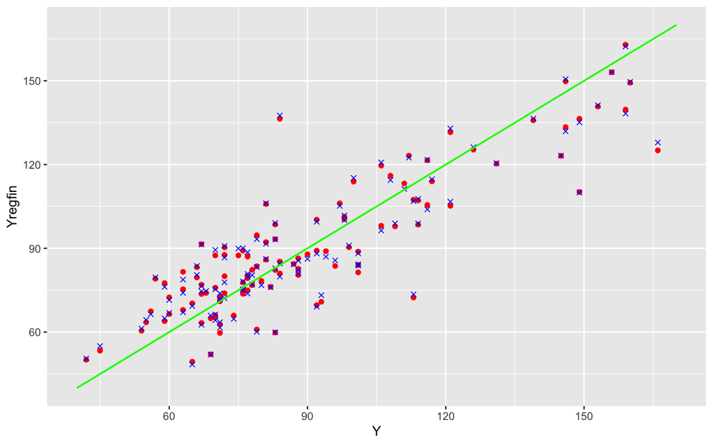

```r
df <- data.frame(Y = oz_quanti$maxO3, Yregfin = reg.fin$fitted.values, Yregcomplet = reg$fitted.values)
ggplot(df) + geom_point(aes(x = Y, y = Yregfin), col = "red") + geom_point(aes(x = Y,
    y = Yregcomplet), col = "blue", shape = 4) + geom_segment(aes(x = 40, y = 40,
    xend = 170, yend = 170), col = "green")
```

## Question 6

### Enoncé

Comparez les valeurs de SSE, SSR et $R^2$ entre le modèle simplifié (*reg.fin*) et le modèle complet (*reg*)

### Correction

```r
SST <- sum((oz_quanti$maxO3 - mean(oz_quanti$maxO3))^2)
# modèle simplifié
SSR.fin <- sum(reg.fin$residuals^2)
SSE.fin <- SST - SSR.fin
R2.fin <- 1 - (SSR.fin/SST)
# modèle complet
SSR.complet <- sum(reg$residuals^2)
SSE.complet <- SST - SSR.complet
R2.complet <- 1 - (SSR.complet/SST)
```

|  | SST | SSR | SSE | R2 |
| --- | --- | --- | --- | --- |
| reg.fin | 88191.68 | 20970.24 | 67221.44 | 0.7622198 |
| reg.complet | 88191.68 | 20827.23 | 67364.45 | 0.7638413 |

# ANOVA à un facteur

Dans cette section, nous souhaitons analyser la relation entre la concentration maximale d’ozone (maxO3) et la direction du vent (vent). On va pour cela mettre en place un modèle d’ANOVA à un facteur

$$\left\{\begin{array}{l} maxO3_{ij}= \mu + \alpha_i +\varepsilon_{ij},\ \
i=1,\ldots,I=4,\ j=1,\ldots,n_i.\\ (\varepsilon_{ij})_{i,j} \textrm{ i.i.d
}\mathcal{N}(0,\sigma^2) \end{array}\right.$$

## Question 1

### Enoncé

Représentez la concentration maximale d’ozone en fonction du vent. Commentez

```r
ggplot(ozone, aes(x = vent, y = maxO3)) + geom_violin()
```

### Correction

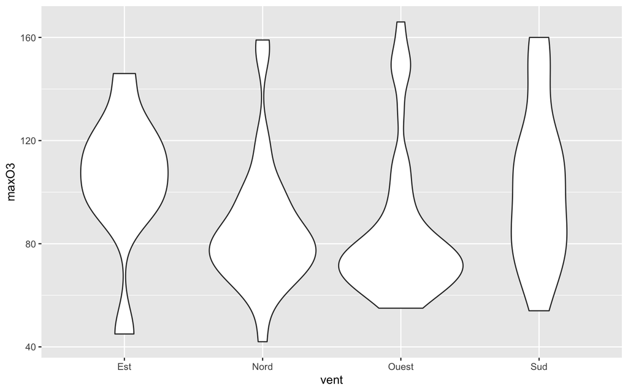

```r
ggplot(ozone, aes(x = vent, y = maxO3)) + geom_violin()
```

Commentaires : on a une différence de distribution de la concentration maximale d’ozone en fonction des modalités du vent. On peut regrouper les comportements entre vent Est et Sud d’un côté, Nord et Ouest de l’autre.

## Question 2

### Enoncé

Utilisez la fonction `lm()` pour ajuster un modèle d’ANOVA à un facteur. Commentez.

```r
# aovent = lm (...)
```

### Correction

```r
aovent <- lm(maxO3 ~ vent, data = ozone)
summary(aovent)
```

```
Call:
lm(formula = maxO3 ~ vent, data = ozone)

Residuals:
    Min      1Q  Median      3Q     Max
-60.600 -16.807  -7.365  11.478  81.300

Coefficients:
            Estimate Std. Error t value Pr(>|t|)
(Intercept)  105.600      8.639  12.223   <2e-16 ***
ventNord     -19.471      9.935  -1.960   0.0526 .
ventOuest    -20.900      9.464  -2.208   0.0293 *
ventSud       -3.076     10.496  -0.293   0.7700
---
Signif. codes:  0 '***' 0.001 '**' 0.01 '*' 0.05 '.' 0.1 ' ' 1

Residual standard error: 27.32 on 108 degrees of freedom
Multiple R-squared:  0.08602,   Adjusted R-squared:  0.06063
F-statistic: 3.388 on 3 and 108 DF,  p-value: 0.02074
```

Commentaires : on retrouve ici les sorties usuelles de la commande `lm`.  
On peut remarquer que le paramètre $\alpha_{sud}$ peut être considéré nul (pvaleur=0.77 pour le test de Student de nullité) ce qui signifie que les vents de l’Est et du Sud ont la même influence sur maxO3.

## Question 3

### Enoncé

A l’aide de la fonction `anova()`, testez la significativité du facteur vent. Commentez.

```r
# anova(....)
```

### Correction

```r
anova(lm(maxO3 ~ 1, data = ozone), aovent)
```

```
Analysis of Variance Table

Model 1: maxO3 ~ 1
Model 2: maxO3 ~ vent
  Res.Df   RSS Df Sum of Sq      F  Pr(>F)
1    111 88192
2    108 80606  3    7586.1 3.3881 0.02074 *
---
Signif. codes:  0 '***' 0.001 '**' 0.01 '*' 0.05 '.' 0.1 ' ' 1
```

Commentaires : On retrouve le test de Fisher de sous-modèle qui est fait par défaut dans la commande `lm()` (cf question 2). Ici $k=4$ et $k_0=1$ donc on retrouve $n-k=$ 108, $n-k_0=$ 111, les valeurs de $SSR$ et $SSR_0$, … La pvaleur $0.02074 \in [0.01,0.05]$ correspond au test de Fisher du modèle blanc $maxO3_{ij} = \mu + \varepsilon_{ij}$ contre le modèle d’anova à un facteur. La p-valeur ne permet pas de trancher clairement entre les deux modèles.

## Question 4

### Enoncé

Comparez les différents résultats obtenus par les commandes suivantes.

```r
summary(lm(maxO3 ~ vent, data = ozone))
```

```
Call:
lm(formula = maxO3 ~ vent, data = ozone)

Residuals:
    Min      1Q  Median      3Q     Max
-60.600 -16.807  -7.365  11.478  81.300

Coefficients:
            Estimate Std. Error t value Pr(>|t|)
(Intercept)  105.600      8.639  12.223   <2e-16 ***
ventNord     -19.471      9.935  -1.960   0.0526 .
ventOuest    -20.900      9.464  -2.208   0.0293 *
ventSud       -3.076     10.496  -0.293   0.7700
---
Signif. codes:  0 '***' 0.001 '**' 0.01 '*' 0.05 '.' 0.1 ' ' 1

Residual standard error: 27.32 on 108 degrees of freedom
Multiple R-squared:  0.08602,   Adjusted R-squared:  0.06063
F-statistic: 3.388 on 3 and 108 DF,  p-value: 0.02074
```

```r
summary(lm(maxO3 ~ C(vent, base = 2), data = ozone))
```

```
Call:
lm(formula = maxO3 ~ C(vent, base = 2), data = ozone)

Residuals:
    Min      1Q  Median      3Q     Max
-60.600 -16.807  -7.365  11.478  81.300

Coefficients:
                   Estimate Std. Error t value Pr(>|t|)
(Intercept)          86.129      4.907  17.553   <2e-16 ***
C(vent, base = 2)1   19.471      9.935   1.960   0.0526 .
C(vent, base = 2)3   -1.429      6.245  -0.229   0.8194
C(vent, base = 2)4   16.395      7.721   2.123   0.0360 *
---
Signif. codes:  0 '***' 0.001 '**' 0.01 '*' 0.05 '.' 0.1 ' ' 1

Residual standard error: 27.32 on 108 degrees of freedom
Multiple R-squared:  0.08602,   Adjusted R-squared:  0.06063
F-statistic: 3.388 on 3 and 108 DF,  p-value: 0.02074
```

```r
summary(lm(maxO3 ~ C(vent, sum), data = ozone))
```

```
Call:
lm(formula = maxO3 ~ C(vent, sum), data = ozone)

Residuals:
    Min      1Q  Median      3Q     Max
-60.600 -16.807  -7.365  11.478  81.300

Coefficients:
              Estimate Std. Error t value Pr(>|t|)
(Intercept)     94.738      3.053  31.027   <2e-16 ***
C(vent, sum)1   10.862      6.829   1.590   0.1147
C(vent, sum)2   -8.609      4.622  -1.863   0.0652 .
C(vent, sum)3  -10.038      4.097  -2.450   0.0159 *
---
Signif. codes:  0 '***' 0.001 '**' 0.01 '*' 0.05 '.' 0.1 ' ' 1

Residual standard error: 27.32 on 108 degrees of freedom
Multiple R-squared:  0.08602,   Adjusted R-squared:  0.06063
F-statistic: 3.388 on 3 and 108 DF,  p-value: 0.02074
```

### Correction

**CAS 1 :**

```r
summary(lm(maxO3 ~ vent, data = ozone))
```

```
Call:
lm(formula = maxO3 ~ vent, data = ozone)

Residuals:
    Min      1Q  Median      3Q     Max
-60.600 -16.807  -7.365  11.478  81.300

Coefficients:
            Estimate Std. Error t value Pr(>|t|)
(Intercept)  105.600      8.639  12.223   <2e-16 ***
ventNord     -19.471      9.935  -1.960   0.0526 .
ventOuest    -20.900      9.464  -2.208   0.0293 *
ventSud       -3.076     10.496  -0.293   0.7700
---
Signif. codes:  0 '***' 0.001 '**' 0.01 '*' 0.05 '.' 0.1 ' ' 1

Residual standard error: 27.32 on 108 degrees of freedom
Multiple R-squared:  0.08602,   Adjusted R-squared:  0.06063
F-statistic: 3.388 on 3 and 108 DF,  p-value: 0.02074
```

Ici, on considère la contrainte $\alpha_{est} = \alpha_1=0$. On a donc pour estimateurs $\hat\mu = Y_{1.}$ et $\alpha_i=Y_{i.}-Y_{1.},\ \forall i\in \{2,3,4\}$.

Vérification :

```r
Yi. = by(ozone[, "maxO3"], ozone[, "vent"], mean)
print(Yi.[1])
```

```
  Est
105.6
```

```r
print(Yi. - Yi.[1])
```

```
ozone[, "vent"]: Est
[1] 0
------------------------------------------------------------
ozone[, "vent"]: Nord
[1] -19.47097
------------------------------------------------------------
ozone[, "vent"]: Ouest
[1] -20.9
------------------------------------------------------------
ozone[, "vent"]: Sud
[1] -3.07619
```

**CAS 2 :**

```r
summary(lm(maxO3 ~ C(vent, base = 2), data = ozone))
```

```
Call:
lm(formula = maxO3 ~ C(vent, base = 2), data = ozone)

Residuals:
    Min      1Q  Median      3Q     Max
-60.600 -16.807  -7.365  11.478  81.300

Coefficients:
                   Estimate Std. Error t value Pr(>|t|)
(Intercept)          86.129      4.907  17.553   <2e-16 ***
C(vent, base = 2)1   19.471      9.935   1.960   0.0526 .
C(vent, base = 2)3   -1.429      6.245  -0.229   0.8194
C(vent, base = 2)4   16.395      7.721   2.123   0.0360 *
---
Signif. codes:  0 '***' 0.001 '**' 0.01 '*' 0.05 '.' 0.1 ' ' 1

Residual standard error: 27.32 on 108 degrees of freedom
Multiple R-squared:  0.08602,   Adjusted R-squared:  0.06063
F-statistic: 3.388 on 3 and 108 DF,  p-value: 0.02074
```

Ici, on considère la contrainte $\alpha_{nord} = \alpha_2=0$. On a donc pour estimateurs $\hat\mu = Y_{2.}$ et $\alpha_i=Y_{i.}-Y_{2.},\ \forall i\in \{1,3,4\}$.

Vérification :

```r
print(Yi.[2])
```

```
    Nord
86.12903
```

```r
print(Yi. - Yi.[2])
```

```
ozone[, "vent"]: Est
[1] 19.47097
------------------------------------------------------------
ozone[, "vent"]: Nord
[1] 0
------------------------------------------------------------
ozone[, "vent"]: Ouest
[1] -1.429032
------------------------------------------------------------
ozone[, "vent"]: Sud
[1] 16.39478
```

**CAS 3 :**

```r
summary(lm(maxO3 ~ C(vent, sum), data = ozone))
```

```
Call:
lm(formula = maxO3 ~ C(vent, sum), data = ozone)

Residuals:
    Min      1Q  Median      3Q     Max
-60.600 -16.807  -7.365  11.478  81.300

Coefficients:
              Estimate Std. Error t value Pr(>|t|)
(Intercept)     94.738      3.053  31.027   <2e-16 ***
C(vent, sum)1   10.862      6.829   1.590   0.1147
C(vent, sum)2   -8.609      4.622  -1.863   0.0652 .
C(vent, sum)3  -10.038      4.097  -2.450   0.0159 *
---
Signif. codes:  0 '***' 0.001 '**' 0.01 '*' 0.05 '.' 0.1 ' ' 1

Residual standard error: 27.32 on 108 degrees of freedom
Multiple R-squared:  0.08602,   Adjusted R-squared:  0.06063
F-statistic: 3.388 on 3 and 108 DF,  p-value: 0.02074
```

Ici la contrainte est $\sum_{i=1}^4 \alpha_i = 0$. Les estimateurs sont $\hat\mu = \frac{1}{I} \sum_{i=1}^I Y_{i.}$ et $\hat\alpha_i = Y_{i.} - \hat\mu$. (Faire les calculs pour vérifier).

```r
print(mean(Yi.))
```

```
[1] 94.73821
```

```r
print(Yi. - mean(Yi.))
```

```
ozone[, "vent"]: Est
[1] 10.86179
------------------------------------------------------------
ozone[, "vent"]: Nord
[1] -8.609178
------------------------------------------------------------
ozone[, "vent"]: Ouest
[1] -10.03821
------------------------------------------------------------
ozone[, "vent"]: Sud
[1] 7.785599
```

```r
sum(as.vector(Yi. - mean(Yi.))[1:3])
```

```
[1] -7.785599
```

## Question 5

### Enoncé

Au vu des différentes conclusions, quelle modification de la variable vent peut-on considérer pour expliquer la concentration en ozone ? Vérifiez numériquement.

### Correction

```r
ozonenew <- ozone[, c("maxO3", "vent")]
ozonenew <- ozonenew %>%
    mutate(vent = str_replace(vent, "Nord", "N-O")) %>%
    mutate(vent = str_replace(vent, "Ouest", "N-O")) %>%
    mutate(vent = str_replace(vent, "Est", "E-S")) %>%
    mutate(vent = str_replace(vent, "Sud", "E-S"))
ozonenew$vent = as.factor(ozonenew$vent)

anova(lm(maxO3 ~ vent, data = ozonenew), lm(maxO3 ~ vent, data = ozone))
```

```
Analysis of Variance Table

Model 1: maxO3 ~ vent
Model 2: maxO3 ~ vent
  Res.Df   RSS Df Sum of Sq      F Pr(>F)
1    110 80709
2    108 80606  2    103.18 0.0691 0.9333
```

```r
summary(lm(maxO3 ~ vent, data = ozonenew))
```

```
Call:
lm(formula = maxO3 ~ vent, data = ozonenew)

Residuals:
    Min      1Q  Median      3Q     Max
-58.516 -16.497  -6.747  11.936  80.753

Coefficients:
            Estimate Std. Error t value Pr(>|t|)
(Intercept)  103.516      4.865  21.278  < 2e-16 ***
ventN-O      -18.269      5.721  -3.194  0.00183 **
---
Signif. codes:  0 '***' 0.001 '**' 0.01 '*' 0.05 '.' 0.1 ' ' 1

Residual standard error: 27.09 on 110 degrees of freedom
Multiple R-squared:  0.08485,   Adjusted R-squared:  0.07653
F-statistic:  10.2 on 1 and 110 DF,  p-value: 0.001833
```

# ANOVA à deux facteurs

Dans cette section, nous souhaitons analyser la relation entre la concentration maximale d’ozone (maxO3) avec la direction du vent (vent) et la précipitation (pluie). On va donc mettre en place un modèle d’analyse de la variance à deux facteurs.

```r
table(ozone$vent, ozone$pluie)
```

```
        Pluie Sec
  Est       2   8
  Nord     10  21
  Ouest    26  24
  Sud       5  16
```

## Question 1

### Enoncé

Représentez la concentration en ozone pour chaque modalité croisée du vent et de la pluie à l’aide de la commande suivante et commentez.

```r
ggplot(ozone, aes(x = vent, y = maxO3, fill = pluie)) + geom_boxplot()
```

### Correction

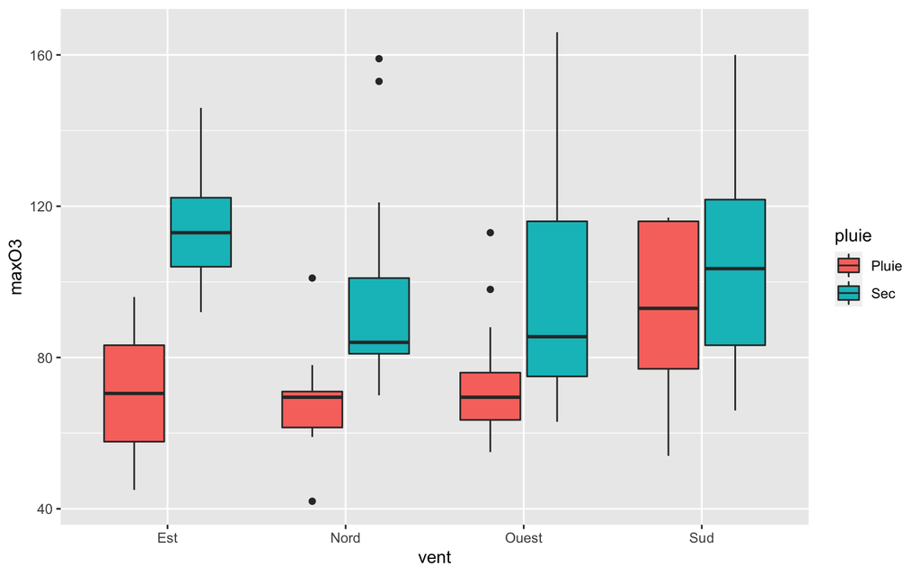

```r
ggplot(ozone, aes(x = vent, y = maxO3, fill = pluie)) + geom_boxplot()
```

Une autre façon d’analyser graphiquement l’interaction est la suivante :

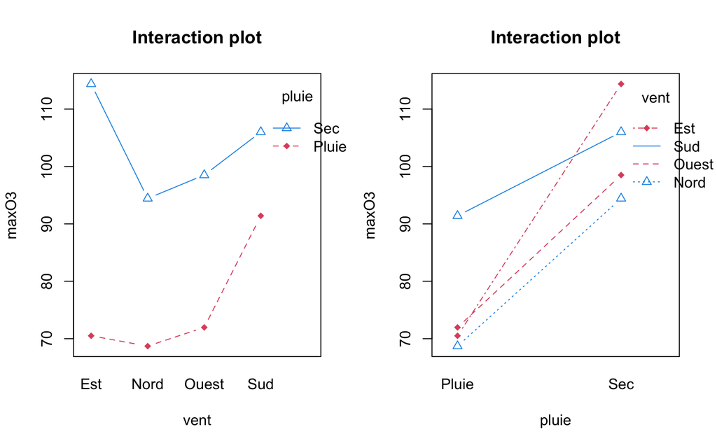

```r
par(mfrow = c(1, 2))
interaction.plot(ozone[, "vent"], ozone[, "pluie"], ozone[, "maxO3"], col = c(2,
    4), pch = c(18, 24), main = "Interaction plot", type = "b", xlab = "vent", ylab = "maxO3",
    trace.label = "pluie")
interaction.plot(ozone[, "pluie"], ozone[, "vent"], ozone[, "maxO3"], col = c(2,
    4), pch = c(18, 24), main = "Interaction plot", type = "b", xlab = "pluie", ylab = "maxO3",
    trace.label = "vent")
```

## Question 2

### Enoncé

Mettez en place un modèle d’analyse de la variance avec interaction. Commentez les résultats.

```r
mod.int <- lm(...)
```

### Correction

$$Y_{ij\ell} = \mu+\alpha_i + \beta_j + \gamma_{ij} + \varepsilon_{ij\ell}$$

```r
mod.int <- lm(maxO3 ~ vent * pluie, data = ozone)
summary(mod.int)
```

```
Call:
lm(formula = maxO3 ~ vent * pluie, data = ozone)

Residuals:
    Min      1Q  Median      3Q     Max
-40.000 -15.971  -3.462   7.635  67.500

Coefficients:
                   Estimate Std. Error t value Pr(>|t|)
(Intercept)          70.500     17.464   4.037 0.000104 ***
ventNord             -1.800     19.131  -0.094 0.925221
ventOuest             1.462     18.123   0.081 0.935881
ventSud              20.900     20.664   1.011 0.314161
pluieSec             43.875     19.526   2.247 0.026749 *
ventNord:pluieSec   -18.146     21.709  -0.836 0.405138
ventOuest:pluieSec  -17.337     20.739  -0.836 0.405117
ventSud:pluieSec    -29.275     23.267  -1.258 0.211138
---
Signif. codes:  0 '***' 0.001 '**' 0.01 '*' 0.05 '.' 0.1 ' ' 1

Residual standard error: 24.7 on 104 degrees of freedom
Multiple R-squared:  0.2807,    Adjusted R-squared:  0.2322
F-statistic: 5.797 on 7 and 104 DF,  p-value: 1.092e-05
```

Commentaires :

- Le $R^2$ est assez faible
- Individuellement, on ne rejette pas la nullité de plusieurs paramètres du modèle. En particulier, tous ceux qui portent l’interaction.
- Pour rappel, pour l’estimation des paramètres R par défaut considère les contraintes $\alpha_1 = \beta_1 = \gamma_{1j} = \gamma_{i1} = 0$.
- On rejette le modèle constant par rapport au modèle complet

## Question 3

### Enoncé

A l’aide de la fonction `anova()`, testez si l’on peut simplifier ce modèle d’ANOVA à deux facteurs avec interaction.

### Correction

On commence par tester si on peut annuler les interactions :

```r
anova(lm(maxO3 ~ vent + pluie, data = ozone), mod.int)
```

```
Analysis of Variance Table

Model 1: maxO3 ~ vent + pluie
Model 2: maxO3 ~ vent * pluie
  Res.Df   RSS Df Sum of Sq    F Pr(>F)
1    107 64446
2    104 63440  3    1006.4 0.55 0.6493
```

On ne rejette pas $H_0$ donc on retient le modèle additif

$$Y_{ij\ell} = \mu + \alpha_i + \beta_j + \varepsilon_{ij\ell}$$

On peut ensuite tester la nullité de l’effet du vent :

```r
anova(lm(maxO3 ~ pluie, data = ozone), lm(maxO3 ~ vent + pluie, data = ozone))
```

```
Analysis of Variance Table

Model 1: maxO3 ~ pluie
Model 2: maxO3 ~ vent + pluie
  Res.Df   RSS Df Sum of Sq      F Pr(>F)
1    110 68238
2    107 64446  3    3791.3 2.0982 0.1048
```

Au risque $5\%$, on ne rejette pas $H_0$ donc pas d’effet du vent.

On peut aussi tester la nullité de l’effet de la pluie :

```r
anova(lm(maxO3 ~ vent, data = ozone), lm(maxO3 ~ vent + pluie, data = ozone))
```

```
Analysis of Variance Table

Model 1: maxO3 ~ vent
Model 2: maxO3 ~ vent + pluie
  Res.Df   RSS Df Sum of Sq      F    Pr(>F)
1    108 80606
2    107 64446  1     16159 26.829 1.052e-06 ***
---
Signif. codes:  0 '***' 0.001 '**' 0.01 '*' 0.05 '.' 0.1 ' ' 1
```

Clairement, on ne peut pas enlever l’effet de la pluie.

Au final, on retient un modèle d’ANOVA avec le facteur pluie

```r
anova(lm(maxO3 ~ pluie, data = ozone), mod.int)
```

```
Analysis of Variance Table

Model 1: maxO3 ~ pluie
Model 2: maxO3 ~ vent * pluie
  Res.Df   RSS Df Sum of Sq      F Pr(>F)
1    110 68238
2    104 63440  6    4797.7 1.3109 0.2589
```

# Analyse de la covariance

Dans cette partie, on s’intéresse à la relation du taux maximal d’ozone (*maxO3*) par rapport à celui de la veille (*maxO3v*) et en fonction des précipitations (*pluie*). Pour cela, on va mettre en place un modèle d’analyse de la covariance.

## Question 1

### Enoncé

A l’aide des commandes suivantes, représentez le nuage de points entre la variable à expliquer *maxO3* et la variable quantitative explicative *maxO3v*, en fonction des modalités de la variable qualitative *pluie*. Commentez.

```r
ggplot(ozone, aes(x = maxO3v, y = maxO3)) + geom_point(aes(shape = pluie, col = pluie))
```

### Correction

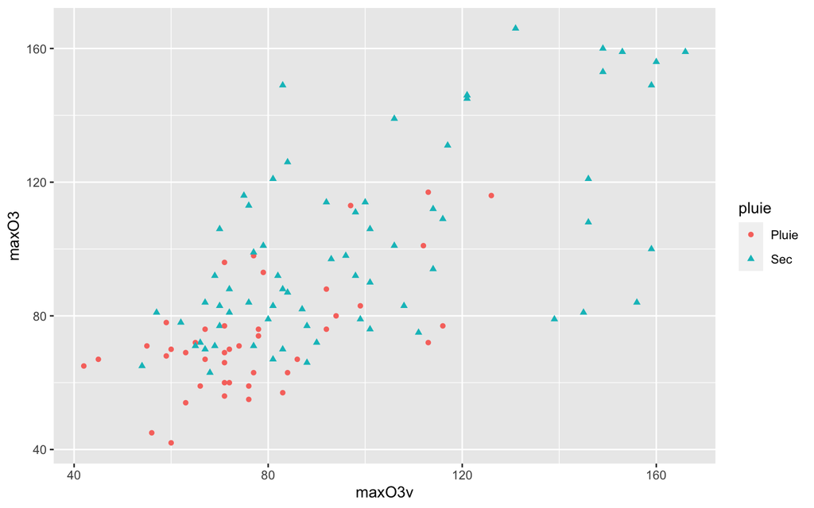

```r
ggplot(ozone, aes(x = maxO3v, y = maxO3)) + geom_point(aes(shape = pluie, col = pluie))
```

## Question 2

### Enoncé

A l’aide de la fonction `lm()` ajustez un modèle d’analyse de covariance avec interaction.

```r
complet <- lm(....)
summary(complet)
```

Graphiquement, on vient d’ajuster les deux droites suivantes :

```r
ggplot(ozone, aes(x = maxO3v, y = maxO3, shape = pluie, col = pluie)) + geom_point() +
    geom_smooth(method = "lm", se = TRUE)
```

### Correction

Modèle complet singulier :

$$maxO3_{ij} = (\mu+\alpha_i) + (\beta+\gamma_i)maxO3v_{ij} + \varepsilon_{ij}$$
avec les contraintes $\alpha_{Pluie} = \gamma_{Pluie} = 0$ :

```r
complet <- lm(maxO3 ~ pluie * maxO3v, data = ozone)
summary(complet)
```

```
Call:
lm(formula = maxO3 ~ pluie * maxO3v, data = ozone)

Residuals:
    Min      1Q  Median      3Q     Max
-50.750 -11.932  -0.926  11.695  57.612

Coefficients:
                Estimate Std. Error t value Pr(>|t|)
(Intercept)     30.24498   12.75140   2.372 0.019467 *
pluieSec        11.84247   15.17665   0.780 0.436916
maxO3v           0.55904    0.16055   3.482 0.000719 ***
pluieSec:maxO3v  0.03494    0.17923   0.195 0.845786
---
Signif. codes:  0 '***' 0.001 '**' 0.01 '*' 0.05 '.' 0.1 ' ' 1

Residual standard error: 19.71 on 108 degrees of freedom
Multiple R-squared:  0.5244,    Adjusted R-squared:  0.5112
F-statistic:  39.7 on 3 and 108 DF,  p-value: < 2.2e-16
```

Modèle complet régulier :

$$maxO3_{ij} = a_i + b_i\ maxO3v_{ij} + \varepsilon_{ij}$$

```r
alt <- lm(maxO3 ~ -1 + pluie + pluie:maxO3v, data = ozone)
summary(alt)
```

```
Call:
lm(formula = maxO3 ~ -1 + pluie + pluie:maxO3v, data = ozone)

Residuals:
    Min      1Q  Median      3Q     Max
-50.750 -11.932  -0.926  11.695  57.612

Coefficients:
                  Estimate Std. Error t value Pr(>|t|)
pluiePluie        30.24498   12.75140   2.372 0.019467 *
pluieSec          42.08745    8.22997   5.114 1.38e-06 ***
pluiePluie:maxO3v  0.55904    0.16055   3.482 0.000719 ***
pluieSec:maxO3v    0.59399    0.07967   7.455 2.37e-11 ***
---
Signif. codes:  0 '***' 0.001 '**' 0.01 '*' 0.05 '.' 0.1 ' ' 1

Residual standard error: 19.71 on 108 degrees of freedom
Multiple R-squared:  0.9581,    Adjusted R-squared:  0.9566
F-statistic: 617.7 on 4 and 108 DF,  p-value: < 2.2e-16
```

Ajustement des droites sur le nuage de points :

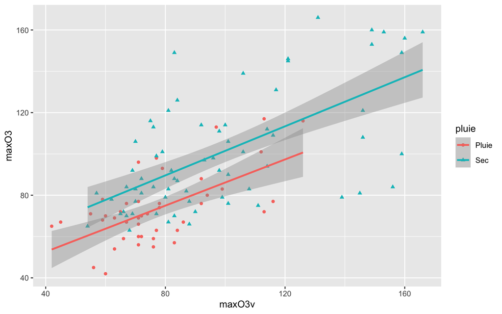

```r
ggplot(ozone, aes(x = maxO3v, y = maxO3, shape = pluie, col = pluie)) + geom_point() +
    geom_smooth(method = "lm", se = TRUE)
```

## Question 3

### Enoncé

A l’aide des commandes suivantes, on teste s’il y a un effet d’interaction entre la variable *pluie* et la variable *max03v* pour expliquer *max03*. Commentez.

```r
penteu <- lm(maxO3 ~ -1 + pluie + maxO3v, data = ozone)
anova(penteu, complet)
```

### Correction

Les commandes suivantes permettent de tester s’il y a un effet d’interaction entre la variable *pluie* et la variable *max03v* pour expliquer *max03*. On met en place un test de Fisher du sous-modèle

$$(M_0) : maxO3_{ij} = a_i + b\ maxO3v_{ij} + \varepsilon_{ij} = (\mu+\alpha_i) + \beta\ maxO3v_{ij} + \varepsilon_{ij}$$
contre le modèle complet.

```r
penteu <- lm(maxO3 ~ -1 + pluie + maxO3v, data = ozone)
anova(penteu, complet)
```

```
Analysis of Variance Table

Model 1: maxO3 ~ -1 + pluie + maxO3v
Model 2: maxO3 ~ pluie * maxO3v
  Res.Df   RSS Df Sum of Sq     F Pr(>F)
1    109 41957
2    108 41943  1    14.762 0.038 0.8458
```

Commentaire : la pvaleur vaut $0.8458\geq 0.05$ donc on ne rejette pas $H_0$ au risque $5\%$ donc on retient le sous-modèle avec l’égalité des pentes.

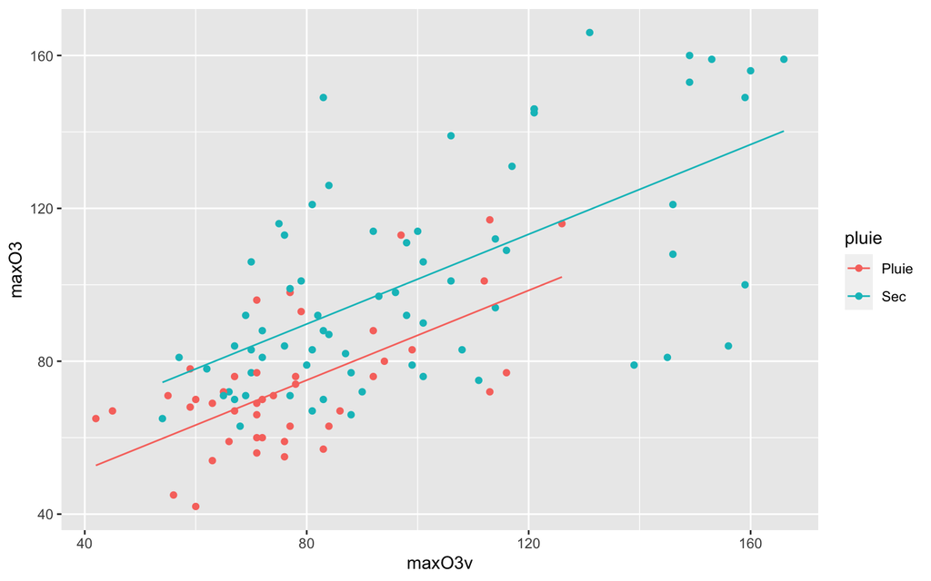

[output not shown]

## Question 4

### Enoncé

Peut-on encore simplifier le modèle ? Mettez en place des tests de Fisher de sous-modèle grâce à la fonction `anova()`.

### Correction

**Effet de la pluie** : On veut tester le sous-modèle suivant
$$maxO3_{ij}=a + b\ maxO3v_{ij}+\varepsilon_{ij}= \mu + \beta\ maxO3v_{ij}+\varepsilon_{ij}$$

contre

$$maxO3_{ij} = a_i + b\ maxO3v_{ij} + \varepsilon_{ij} = (\mu+\alpha_i) + \beta\ maxO3v_{ij}+\varepsilon_{ij}$$

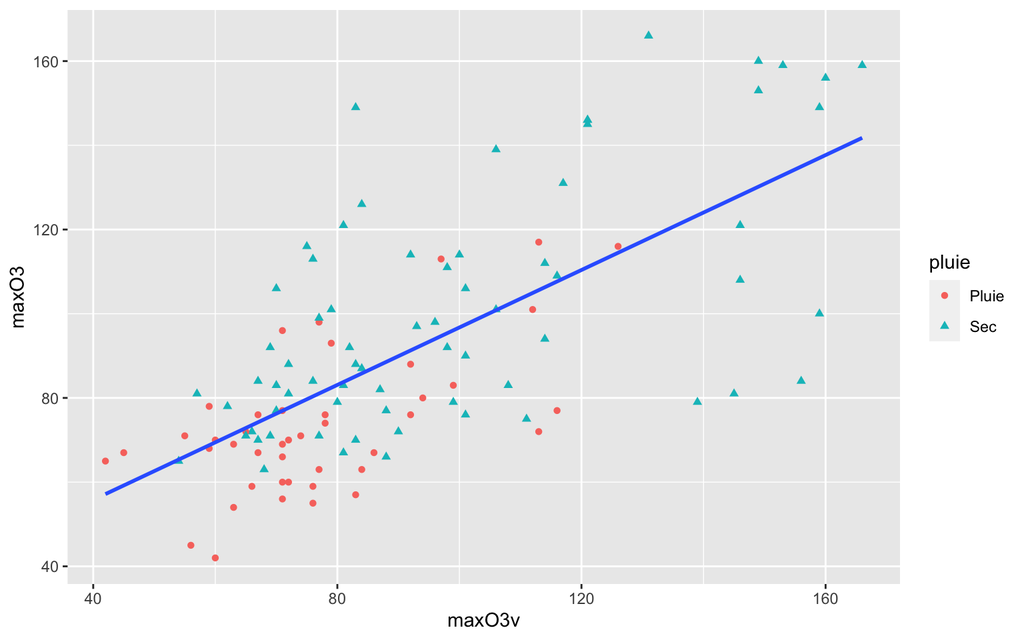

```r
simple <- lm(maxO3 ~ maxO3v, data = ozone)
ggplot(ozone, aes(x = maxO3v, y = maxO3)) + geom_point(aes(shape = pluie, col = pluie)) +
    geom_smooth(method = "lm", se = FALSE)
```

```r
anova(simple, penteu)
```

```
Analysis of Variance Table

Model 1: maxO3 ~ maxO3v
Model 2: maxO3 ~ -1 + pluie + maxO3v
  Res.Df   RSS Df Sum of Sq      F    Pr(>F)
1    110 46868
2    109 41957  1      4911 12.758 0.0005291 ***
---
Signif. codes:  0 '***' 0.001 '**' 0.01 '*' 0.05 '.' 0.1 ' ' 1
```

On rejette le sous-modèle de régression linéaire. Donc on conserve le modèle avec effet de la pluie et de maxO3v mais sans interaction.

**Test d’effet de maxO3v**

On veut tester le sous-modèle suivant
$$maxO3_{ij} = a_i +\varepsilon_{ij} = \mu + \alpha_i + \varepsilon_{ij}$$

contre

$$maxO3_{ij} = a_i + b\ maxO3v_{ij} + \varepsilon_{ij} = (\mu+\alpha_i) + \beta\ maxO3v_{ij} + \varepsilon_{ij}$$

```r
anov1 <- lm(maxO3 ~ pluie, data = ozone)
anova(anov1, penteu)
```

```
Analysis of Variance Table

Model 1: maxO3 ~ pluie
Model 2: maxO3 ~ -1 + pluie + maxO3v
  Res.Df   RSS Df Sum of Sq      F    Pr(>F)
1    110 68238
2    109 41957  1     26280 68.272 3.734e-13 ***
---
Signif. codes:  0 '***' 0.001 '**' 0.01 '*' 0.05 '.' 0.1 ' ' 1
```

On rejette le sous-modèle d’Anova à un facteur. Donc on conserve le modèle avec effet de la pluie et de maxO3v mais sans interaction.